# Rapport de Projet : Analyse Factorielle Discriminante des Sentiments Twitter

## 1 Introduction

Le jeu de données “Twitter Entity Sentiment Analysis” comprend des tweets classés par **entité** (marques, jeux vidéo,…) et par **4 sentiments** (Positive, Negative, Neutral, Irrelevant). L’objectif de ce projet va être de transformer ces données textuelles non structurées en vecteurs numériques afin d’appliquer **l’Analyse Factorielle Discriminante (AFD)**. Nous cherchons à savoir si les caractéristiques lexicales des tweets permettent de séparer distinctement les catégories de sentiments dans un espace de dimension réduite.

## 2 Chargement et pré-traitement des données

**La première partie consiste en la préparation des données. Sans un nettoyage rigoureux, l’AFD ne produirait que du bruit et biaiserait fortement nos résultats.**

### 2.1 Les librairies

Tout d’abord, on vient définir les librairies qui vont être utilisés dans l’ensemble du code. Chaque package a un rôle spécifique pour transformer du texte brut en données mathématiques :

- **tidyverse** : La base pour manipuler les données.
- **textclean/tm** : Des outils spécialisés dans le nettoyage de texte.
- **SnowballC** : Utilisé pour le *stemming*.
- **text2vec** : Un package très performant pour transformer le texte en vecteurs numériques.
- **MASS** : Contient la fonction *lda()*, c’est le moteur de l’AFD.
- **Matrix** : Permet de gérer les “matrices creuses”, ce qui économise énormément de mémoire vive.
- **ggplot2** : Utilisé pour visualiser nos résultats à travers des graphiques, schémas,…

```r
library(tidyverse)
library(textclean)
library(tm)
library(SnowballC)
library(text2vec)
library(MASS)
library(Matrix)
```

```r
library(ggplot2)
```

### 2.2 Chargement

Nous chargeons nos fichiers CSV grâce à la fonction *read_csv()*. On définit nos paramètres de tel sorte à ce que R ne convertit pas en catégorie et remplissent les case vides en NA pour *“Not available”*. On renomme également nos colonnes afin d’avoir une vision plus claire et lisible de notre code.

```r
train <- read.csv("twitter_training.csv", stringsAsFactors = FALSE, na.strings = c("", "NA"), fileEncoding = "UTF-8")
test  <- read.csv("twitter_validation.csv", stringsAsFactors = FALSE, na.strings = c("", "NA"), fileEncoding = "UTF-8")

colnames(train) <- c("id", "Company", "Sentiment", "Tweet")
colnames(test)  <- c("id", "Company", "Sentiment", "Tweet")
```

```r
head(train,5)
```

```
##     id     Company Sentiment
## 1 2401 Borderlands  Positive
## 2 2401 Borderlands  Positive
## 3 2401 Borderlands  Positive
## 4 2401 Borderlands  Positive
## 5 2401 Borderlands  Positive
##                                                       Tweet
## 1       I am coming to the borders and I will kill you all,
## 2        im getting on borderlands and i will kill you all,
## 3       im coming on borderlands and i will murder you all,
## 4 im getting on borderlands 2 and i will murder you me all,
## 5     im getting into borderlands and i can murder you all,
```

### 2.3 Nettoyage

C’est ici que l’on vient transformer le tweet humain en une **suite de mots** exploitables par un algorithme ; c’est-à-dire sans caractère spécial.

On crée alors la fonction **cleaning** qui va effectuer ces lignes dans **l’ordre suivant :**

```r
# Supprimer les lignes vides tout d'abord
train <- train %>% drop_na(Tweet, Sentiment)
test  <- test %>% drop_na(Tweet, Sentiment)

# Fonction de nettoyage
cleaning <- function(text) {
  if (is.na(text) || nchar(text) == 0) return("")
  text <- replace_url(text)
  text <- tolower(text)
  text <- gsub("[^a-z]", " ", text)
  text <- removeWords(text, stopwords("en"))
  text <- wordStem(text)  # stemming
  text <- gsub("\\s+", " ", text)
  text <- trimws(text)
  return(text)
}
```

### 2.4 Application

On applique la fonction à nos colonnes “Tweet” du CSV *training et validation*. On utilise la fonction *sapply()*.

**==> Très important ! Après avoir supprimé les URLs et les mots vides, certaines cases peuvent devenir totalement vides. Si vous les gardez, l’AFD plantera car elle ne peut pas analyser un tweet sans mots.**

Une fois toutes les étapes effectuées, on transforme la colonne *Sentiment* en **catégories** (Positive, Negative, etc.). C’est indispensable pour l’AFD car elle a besoin de savoir quelles sont les “classes” à séparer.

```r
train$clean_tweet <- sapply(train$Tweet, cleaning)
test$clean_tweet  <- sapply(test$Tweet, cleaning)

# Supprimer les tweets vides après nettoyages + Conversion en catégories
train <- train[nchar(train$clean_tweet) > 0, ]
test  <- test[nchar(test$clean_tweet) > 0, ]

train$Sentiment <- as.factor(train$Sentiment)
test$Sentiment  <- as.factor(test$Sentiment)
```

```r
head(train,5)
```

```
##     id     Company Sentiment
## 1 2401 Borderlands  Positive
## 2 2401 Borderlands  Positive
## 3 2401 Borderlands  Positive
## 4 2401 Borderlands  Positive
## 5 2401 Borderlands  Positive
##                                                       Tweet
## 1       I am coming to the borders and I will kill you all,
## 2        im getting on borderlands and i will kill you all,
## 3       im coming on borderlands and i will murder you all,
## 4 im getting on borderlands 2 and i will murder you me all,
## 5     im getting into borderlands and i can murder you all,
##                          clean_tweet
## 1           coming borders will kill
## 2   im getting borderlands will kill
## 3  im coming borderlands will murder
## 4 im getting borderlands will murder
## 5  im getting borderlands can murder
```

==> On voit qu’on a réussi à obtenir une colonne *clean_tweet* composée de mots importants pour la suite.

## 3 Ingénierie des caractéristiques

**Cette deuxième phase est celle de la vectorisation. Le but est de transformer nos mots nettoyés en nombres pour que l’algorithme de l’AFD puisse effectuer des calculs matriciels.**

### 3.1 Création du vocabulaire

Afin de créer un dictonnaire de données, on va utiliser une méthode de text2vec, s’appelant *itoken()*. Cette fonction forme un itérateur, qui vient découper nos phrases en **unités individuelles** et donc, évite de charger tout le texte en mémoire d’un coup.

```r
it_train <- itoken(train$clean_tweet, progressbar = TRUE)
it_test  <- itoken(test$clean_tweet, progressbar = TRUE)
```

Maintenant, on construit le **vocabulaire des tweets.** On prend la fonction *prune_vocabulary()*, qui ira sélectionner des mots précis, grâce à ses paramètres :

- *term_count_min = n :* Elimine les mots qui apparaissent **moins de n fois.** S’ils sont trop rares, ils ne peuvent pas aider à généraliser un sentiment.
- *doc_proportion_max = 0.5 :* On élimine les mots qui sont présents dans **plus de la moitié des tweets** (ex: “game”, “twitter”). S’ils sont partout, ils ne permttront pas une distiction entre les sentiments.
- *vocab_term_max = 500 :* C’est la décision la plus **importante.** L’AFD ne supporte pas d’avoir trop de colonnes. En limitant à 500 mots, on s’assure que le modèle reste **calculable et stable.**

```r
vocab <- create_vocabulary(it_train, ngram = c(1, 3))
vocab <- prune_vocabulary(vocab,
                          term_count_min = 10,
                          doc_proportion_max = 0.5,
                          vocab_term_max = 500)

vectorizer <- vocab_vectorizer(vocab)
```

*P.S. : Le choix du nombres de colonnes est très important pour le bon fonctionnement du code. En effet, en gardant le nombre maximal, on risque de se frotter à 2 erreurs : une instabilité de calcul dans l’AFD ou bien une explosion de la mémoire.*

#### 3.1.1 Améliorations (pour le vocabulaire)

**1.1.** Lors des premiers tests, On observait que l’accuracy de notre code était très mauvaise (~20%). Cela signifie que notre modèle n’avait pas pu correctement séparer nos sentiments dans différentes classes.

Une des raisons était lié à notre liste de vocabulaire : en effet, elle retournait le tweet traité en une longue phrase de lettres collées les unes aux autres, ne facilitant la lecture de la sémantique. Nous avions alors modifié notre fonction “cleaning” afin de pouvoir garder les mots séparées une fois le traitement effectué. Cette action nous a permis de mieux vectoriser chaque paramètre. En effet, grâce à cette action, notre “accuracy” a pu doubler son pourcentage (~50%) et ainsi, montrer une meilleure AFD.

**1.2.** On peut encore faire mieux. Puisque l’on veut faciliter le choix dans le vocabulaire, une étape “intermédiaire” classique pour booster l’AFD consiste à ne pas regarder seulement les mots seuls, mais aussi les paires de **mots (bigrammes, trigrammes,…)**. En effet, dans l’analyse des sentiments, on peut avoir les mots individuels “not” et “good” côte à côte, mais considérés comme 2 mots distincts, ce qui fausse nos résultats.

Ainsi on modifie notre paramètre *vocab* et ainsi, offrir plus de possibilités et combinaisons de champs lexicaux. Encore une fois, ce changement a permis une meilleure précision.

### 3.2 Création des matrices TF-IDF

Le texte est maintenant transformé en une matrice où chaque ligne est un tweet et chaque colonne est un mot de vocabulaire.

On utilise *create_dtm* pour créer la Document-Term Matrix. De là, on applique la **pondération TF-IDF**. Donc :

- Plus un mot est présent dans un tweet, plus il est important.
- Si un mot est présent dans beaucoup de tweets différents, on diminue son importance car il est banal.

==> En résumé, un mot dit “excellent” recevra un score élevé s’il est rare dans le corpus global mais présent dans le tweet analysé.

```r
dtm_train <- create_dtm(it_train, vectorizer)
dtm_test  <- create_dtm(it_test, vectorizer)

tfidf <- TfIdf$new()
dtm_train_tfidf <- tfidf$fit_transform(dtm_train)
dtm_test_tfidf  <- tfidf$transform(dtm_test)
```

### 3.3 Conversion

Ici, nous devons convertir nos résultats en une **dataFrame** puisque l’algorithme lda() du package MASS ne travaille pas avec les objets spécifiques de text2vec.

```r
X_train <- as.matrix(dtm_train_tfidf)
X_test  <- as.matrix(dtm_test_tfidf)

data_train_afd <- data.frame(Sentiment = train$Sentiment, X_train)
data_test_afd  <- data.frame(Sentiment = test$Sentiment, X_test)
```

Et voilà, on obtient les informations nécessaires pour effectuer nos recherches !

## 4 Analyse factorielle discriminante (AFD)

**C’est ici que l’Analyse Factorielle Discriminante commence.**

### 4.1 Principe

L’analyse factorielle discriminante consiste à trouver une succession d’axes factoriels, tous orthogonaux entre eux et qui maximisent les projections des distances entre les groupes. Ces axes, appelés **fonctions discriminantes**, sont construits de manière à séparer au mieux les classes définies a priori. L’objectif est double :

- **Maximiser la variance inter‑groupes :** les centres de gravité des groupes doivent être aussi éloignés que possible lorsqu’ils sont projetés sur les axes discriminants.
- **Minimiser la variance intra‑groupe :** les individus appartenant à un même groupe doivent rester proches les uns des autres.

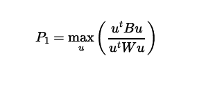

où :

- **B** est la matrice de dispersion inter‑groupes,
- **W** est la matrice de dispersion intra‑groupe,
- **u** est le vecteur discriminant recherché.

Dans le cadre de ce projet, l’AFD va donc :

- **Réduire la dimensionnalité :** le texte original transformé par TF-IDF va diminuer pour ne prendre que l’essentiel des messages.
- **Séparer les sentiments :** l’AFD va chercher spécifiquement les axes qui séparent le mieux les tweets ‘Positive’, ‘Negative’, ‘Neutral’, ‘Irrelevant’.

### 4.2 Modèle AFD

On vient chercher un relation entre **un Sentiment et toutes les autres colonnes (500 mots de vocabulaire).** L’algorithme calcule des vecteurs qui maximisent la séparation entre les groupes (Positive, Negative, etc.).  
Par exemple, si le mot “bad” apparaît souvent dans le groupe “Négatif” et jamais ailleurs, l’AFD va donner un **poids très fort** à ce mot pour construire l’axe de séparation.

```r
lda_model <- lda(Sentiment ~ ., data = data_train_afd)
lda_train <- predict(lda_model, data_train_afd)
lda_test  <- predict(lda_model, data_test_afd)
```

### 4.3 La projection et dataframe de visualisation

```r
lda_df_train <- data.frame(
  LD1 = lda_train$x[,1],
  LD2 = lda_train$x[,2],
  Sentiment = data_train_afd$Sentiment
)
```

```r
head(lda_df_train,5)
```

```
##          LD1        LD2 Sentiment
## 1 -1.6595549 -0.5324506  Positive
## 2 -0.3625347 -0.4242826  Positive
## 3 -1.4448062 -1.1251411  Positive
## 4 -0.1668316 -0.7601285  Positive
## 5  0.2586257 -0.6262978  Positive
```

## 5 Visualisation

### 5.1 Graphique 1

On génère le graphique visuel avec *ggplot2().* On place les tweets sur les axes de séparation trouvés par l’AFD.

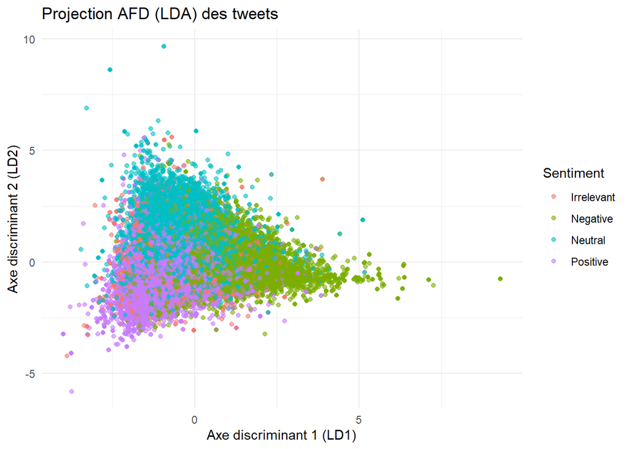

```r
p <- ggplot(lda_df_train, aes(x = LD1, y = LD2, color = Sentiment)) +
  geom_point(alpha = 0.6) +
  theme_minimal() +
  labs(
    title = "Projection AFD (LDA) des tweets",
    x = "Axe discriminant 1 (LD1)",
    y = "Axe discriminant 2 (LD2)",
    color = "Sentiment"
  )

p
```

Chaque point représente un tweet. La couleur représente le Sentiment auquel le tweet a été attribué.

**==> On peut observer alors une séparation discriminante correcte : on a les tweets “Positive”, “Negative” et “Neutral” qui sont majoritairement répartits entre eux.**

==> On observe également que les tweets “Irrelevant” se chevauchent entre les différentes classes. Ceci est un bon indicatif, car les tweets neutres partagent du vocabulaire avec toutes les autres classes, étant donné que les mots utilisés ne sont pas distincts des autres. Ainsi, l’AFD ne peut séparer que ce qui est réellement discriminant dans ces données.

### 5.2 Graphique 2

On génère un autre graphique visuel avec *ggplot2()*. On regarde cette fois les distributions des sentiments selon l’axe principal.

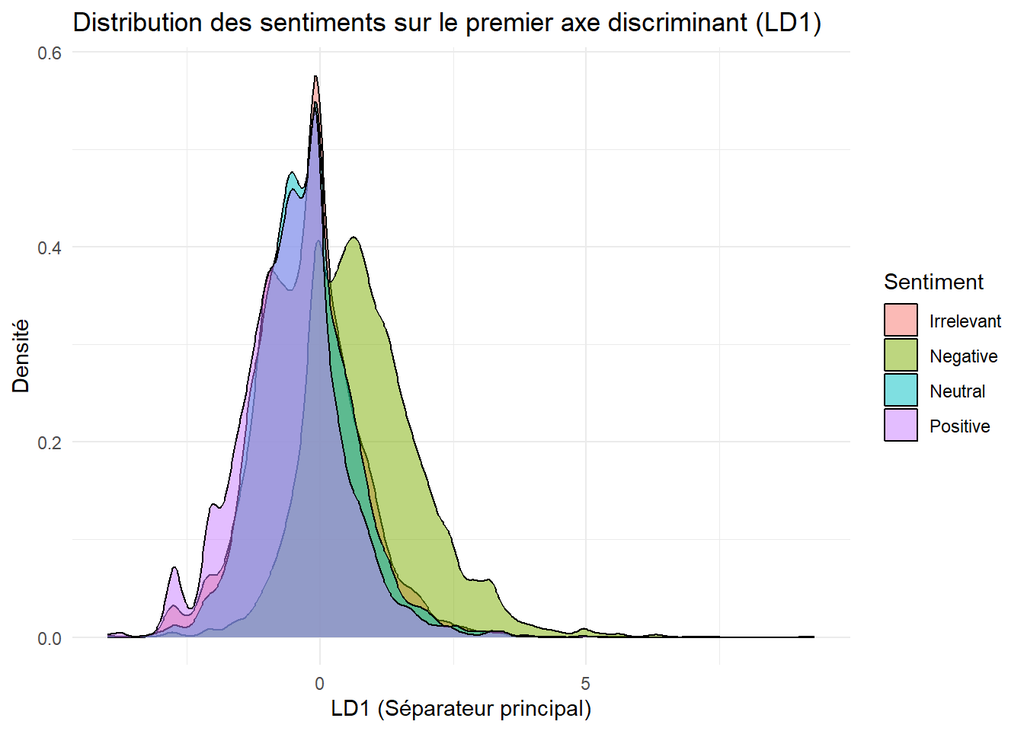

```r
q <-ggplot(lda_df_train, aes(x = LD1, fill = Sentiment)) +
  geom_density(alpha = 0.5) +
  theme_minimal() +
  labs(title = "Distribution des sentiments sur le premier axe discriminant (LD1)",
       x = "LD1 (Séparateur principal)",
       y = "Densité")

q
```

## 6 Evaluation du modéle

```r
pred_test <- lda_test$class
confusion <- table(Predicted = pred_test, Actual = data_test_afd$Sentiment)
print(confusion)
```

```
##             Actual
## Predicted    Irrelevant Negative Neutral Positive
##   Irrelevant         51       11      14       14
##   Negative           44      182      73       39
##   Neutral            28       33     135       37
##   Positive           48       39      63      187
```

```r
accuracy <- sum(diag(confusion)) / sum(confusion)
accuracy
```

```
## [1] 0.5561122
```

## 7 Travaux futurs

Ce mini projet pourrait être amélioré et cet analyse plus poussée, sur plusieurs points :

1. **Ponctuation expressive :** Dans un message écrit, la ponctuation joue un rôle très important dans l’interprétation des sentiments d’un individu. C’est le moyen de communication le plus distinctif, qui fait la différence. Un exemple serait celui-ci :
- “Génial !” –> Enthousiasme,
- “Génial…” –> Agaçement,
- “Génial !?” –> Incompréhension,
- “Génial.” –> Indifférence.

**==> Ces petits caractères se révèlent être de grands atouts et facteurs importants pour une analyse des émotions. On peut alors chercher à vouloir les intégrer à notre code, afin d’avoir une meilleure caractérisation des tweets.**

2. **Plus de données :** Le plus évident serait bien évidemment, d’augmenter la taille des données à analyser. Un tweet est un indicateur d’émotion directe, mais il reste dépendant du contexte dans lequel il est écrit :
- Quelqu’un peut faire une critique d’un jeu mais pour autant ne pas être négatif (ex : critique constructive, avis nuancé),
- D’autres peuvent utiliser le sarcasme et la ponctuation pour exprimer leur avis, ce qui est difficilement identifiable pour ces machines.

**==> Avoir plus de matière et de contexte, comme des avis plus poussés ans la réflexion, aiderait grandement une meilleure compréhension des sentiments.**

3. **Modèle plus lisse ? :** Comme nous le savons, l’analyse discriminative linéaire va chercher des combinaisons linéaires des variables pour séparer les classes. Or bien souvent, un mot ne définit pas forcément l’émotion recherchée. Justement, lorsque nous réalisons les bigrammes, on cherche des ensembles de mots qui permettent de mieux définir les sentiments :
- *“good” –> Positive*
- “Not good” –> Negative

Mais la LDA simple générale prend les mots individuellement et donc ne capturent pas ces relations sémantiques.

En questionnant des sites web et les IA de recherche, il existe une alternative nommée SVM ou *“Support Vector Machine”*. C’est un nouveau modèle qui est capable d’apprendre des notions non linéaires. Au delà de ça, elle peut gérer des données à dimension haute et creuses, qualité que ne possède pas LDA.

**==> Je pense alors que modifier notre approche de modélisation pourrait avoir un impact sur la qualité d’analyse du code à l’avenir.**